# Tugas MPDW Pertemuan 2

### Membangkitkan library yang dibutuhkan

```r
library("forecast")
```

```r
library("graphics")
library("TTR")
library("TSA")
library("lmtest")
library("orcutt")
library("HoRM")
library("GGally")
library("ggplot2")
library("SciViews")
```

### Impor Data

```r
library(rio)
tugas <- import("https://raw.githubusercontent.com/Prratama/MPDW/main/Data/mpdw2.csv")
str(tugas)
```

```
## 'data.frame':    151 obs. of  3 variables:
##  $ high  : num  14.5 14.7 14.8 14.7 14.8 ...
##  $ low   : num  14.2 14.3 14.5 14.6 14.6 ...
##  $ volume: int  13424502 5890059 15573948 22498722 8925387 3612902 8882964 5203714 8318238 6682411 ...
```

```r
dim(tugas)
```

```
## [1] 151   3
```

### Mendefinisikan setiap peubah yang akan digunakan

```r
tinggi <- c(tugas$high)
rendah <- c(tugas$low)
total <- c(tugas$volume)
gabung <- cbind(tinggi,rendah,total)
gabung <- as.data.frame(gabung)
gabung
```

| tinggi | rendah | total |
| --- | --- | --- |
| 14.53 | 14.19 | 13424502 |
| 14.70 | 14.33 | 5890059 |
| 14.77 | 14.53 | 15573948 |
| 14.69 | 14.55 | 22498722 |
| 14.84 | 14.65 | 8925387 |
| 14.81 | 14.63 | 3612902 |
| 14.77 | 14.66 | 8882964 |
| 14.59 | 14.37 | 5203714 |
| 14.52 | 14.36 | 8318238 |
| 14.47 | 14.23 | 6682411 |

[output cut: 141 more lines]

### Membuat data time series

```r
datats1 <- ts(gabung$tinggi)
datats2 <- ts(gabung$rendah)
datats3 <- ts(gabung$total)
datats1
```

```
## Time Series:
## Start = 1
## End = 151
## Frequency = 1
##   [1] 14.53 14.70 14.77 14.69 14.84 14.81 14.77 14.59 14.52 14.47 13.90 13.89
##  [13] 13.94 13.94 14.07 14.18 13.93 13.94 13.94 13.78 14.10 14.14 13.94 13.87
##  [25] 13.83 13.85 13.73 13.89 13.97 14.00 14.00 13.90 13.72 13.47 13.41 13.40
##  [37] 13.56 14.32 14.64 14.68 14.59 14.67 14.57 14.41 14.09 13.74 13.65 13.51
##  [49] 13.38 13.28 13.21 13.26 13.10 12.80 12.59 12.82 12.77 12.87 12.94 12.83
##  [61] 12.66 12.74 12.88 13.08 13.38 13.45 13.47 13.59 13.92 13.78 13.92 14.19
##  [73] 14.27 14.01 14.10 14.41 14.28 14.15 14.34 14.34 14.33 14.38 14.14 14.27
##  [85] 14.44 14.43 14.45 14.32 13.95 13.87 14.10 14.18 14.16 14.38 14.56 14.54
##  [97] 14.77 14.82 14.95 14.74 14.67 14.69 14.78 15.00 15.03 15.19 15.11 15.10
## [109] 15.31 15.20 15.59 15.66 15.41 15.24 15.16 15.07 15.19 14.90 14.78 14.77
## [121] 14.78 14.76 14.59 14.51 14.70 14.75 14.69 14.67 14.52 14.44 14.41 14.13
## [133] 14.39 14.50 14.69 14.66 14.44 14.47 14.44 14.53 14.47 14.13 14.11 14.00
## [145]    NA    NA    NA    NA    NA    NA    NA
```

```r
datats2
```

```
## Time Series:
## Start = 1
## End = 151
## Frequency = 1
##   [1] 14.19 14.33 14.53 14.55 14.65 14.63 14.66 14.37 14.36 14.23 13.64 13.58
##  [13] 13.69 13.61 13.87 13.88 13.71 13.81 13.70 13.60 13.88 13.94 13.77 13.70
##  [25] 13.72 13.72 13.59 13.60 13.81 13.85 13.86 13.77 13.49 13.26 13.23 13.28
##  [37] 13.31 13.82 14.30 14.40 14.47 14.28 14.39 14.18 13.76 13.51 13.40 13.13
##  [49] 13.15 13.04 12.94 12.85 12.65 12.36 12.44 12.56 12.56 12.63 12.68 12.52
##  [61] 12.45 12.53 12.53 12.73 13.09 13.23 13.26 13.36 13.49 13.60 13.72 13.94
##  [73] 14.01 13.69 13.83 14.10 13.82 13.86 13.98 14.07 14.14 14.09 13.91 14.03
##  [85] 14.23 14.22 14.23 13.97 13.63 13.70 13.74 13.80 13.77 14.02 14.36 14.37
##  [97] 14.51 14.57 14.64 14.46 14.47 14.56 14.56 14.78 14.89 15.00 14.90 14.86
## [109] 14.67 15.01 15.19 15.39 15.09 14.92 14.88 14.86 14.94 14.63 14.60 14.56
## [121] 14.58 14.56 14.38 14.36 14.47 14.64 14.55 14.47 14.39 14.25 14.08 13.98
## [133] 14.09 14.33 14.35 14.43 14.23 14.35 14.18 14.28 14.35 13.95 13.94 13.91
## [145]    NA    NA    NA    NA    NA    NA    NA
```

```r
datats3
```

```
## Time Series:
## Start = 1
## End = 151
## Frequency = 1
##   [1] 13424502  5890059 15573948 22498722  8925387  3612902  8882964  5203714
##   [9]  8318238  6682411 12793686 15307766 18840551 13791032 17338661 16301536
##  [17] 11804556  8324545  5230154  5851206 10412003  4596950  6998882  6132208
##  [25]  3717757  4183782  6763637 10180377  8810005  7462331  6554679 16487387
##  [33]  4659265  7134270  7686244  4728196 15866847 32448282  9656115 16305535
##  [41] 15149883 15653859 14594872  3636173  6627375  5569305  4819873 13049548
##  [49]  7055457  6931066  6919282  6409728 10325603  5751405  6267801  4525228
##  [57]  6881706  5700491  6467407 12567367  1917867 12347131 21470838  5708439
##  [65]  8635970  5085282  7990633  7397860  8994851  6581679  6587844  6067110
##  [73]  4875022  6150337  6733473 10026824 13383773  7069463  7256663 14850615
##  [81]  4590713  4472923  8125033  4205594  6592084  5126424  4678477  9109048
##  [89]  6147404  5020819  5864343  3762971  4715143  5468324  6208875  4052594
##  [97]  8816222  5636046  8908103  6975835  4950950  7777126  4078331  4454748
## [105]  3639909  4449664  5508978  6910004 17400412  6869537  6922644 10035752
## [113] 15736300 11897805  5421084  7725855  4518505  8384914  5301849  5231570
## [121]  4590942  4315984  4468139  5297755  5348788  3487490 15432390  4315801
## [129]  4333479  4250601  6236249  7684944 12602100  8464034  5720010  5006379
## [137]  5181399  5257987  8125332  7409070  7962371  6986347  9080059  6377030
## [145]       NA       NA       NA       NA       NA       NA       NA
```

### Membangkitkan plot dan korelasi

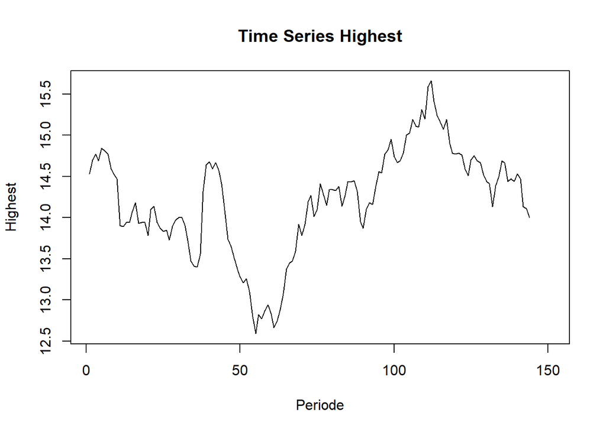

```r
ts.plot(datats1, xlab="Periode", ylab="Highest", main="Time Series Highest")
```

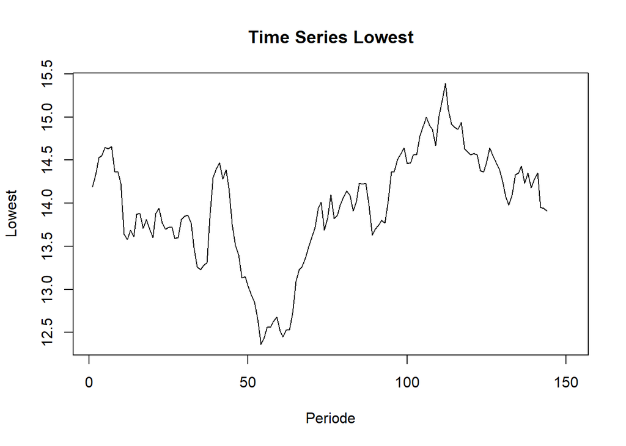

```r
ts.plot(datats2, xlab="Periode", ylab="Lowest", main="Time Series Lowest")
```

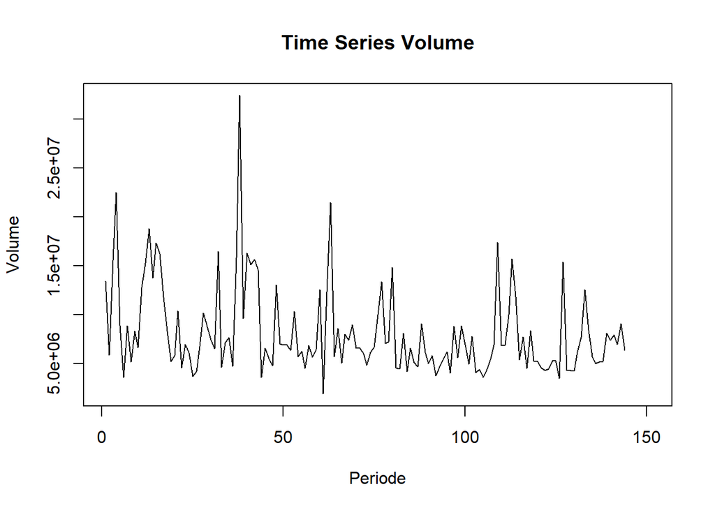

```r
ts.plot(datats3, xlab="Periode", ylab="Volume", main="Time Series Volume")
```

[figure not shown]

```r
plot(total,tinggi, xlab="Highest", ylab="Volume", main="Plot Highest & Volume")
```

[figure not shown]

```r
plot(total, rendah, xlab="Lowest", ylab="Volume", main=" Plot Lowest & Volume")
```

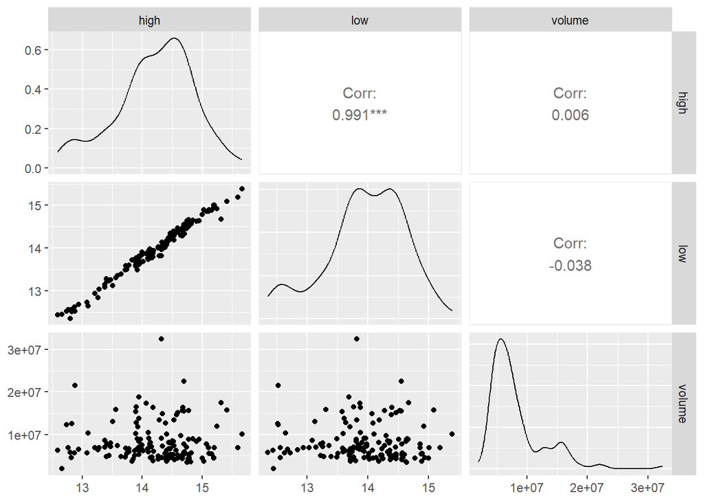

```r
ggpairs(tugas)
```

### Model regresi

```r
reg <- lm(total~tinggi+rendah, data = tugas)
summary(reg)
```

```
##
## Call:
## lm(formula = total ~ tinggi + rendah, data = tugas)
##
## Residuals:
##      Min       1Q   Median       3Q      Max
## -6588673 -2882860 -1076807  1500631 20137137
##
## Coefficients:
##              Estimate Std. Error t value Pr(>|t|)
## (Intercept)   3061402    7999575   0.383 0.702522
## tinggi       16316006    4081034   3.998 0.000103 ***
## rendah      -16237009    4033006  -4.026 9.22e-05 ***
## ---
## Signif. codes:  0 '***' 0.001 '**' 0.01 '*' 0.05 '.' 0.1 ' ' 1
##
## Residual standard error: 4303000 on 141 degrees of freedom
##   (7 observations deleted due to missingness)
## Multiple R-squared:  0.1031, Adjusted R-squared:  0.09041
## F-statistic: 8.107 on 2 and 141 DF,  p-value: 0.0004649
```

### Uji terhadap sisaan

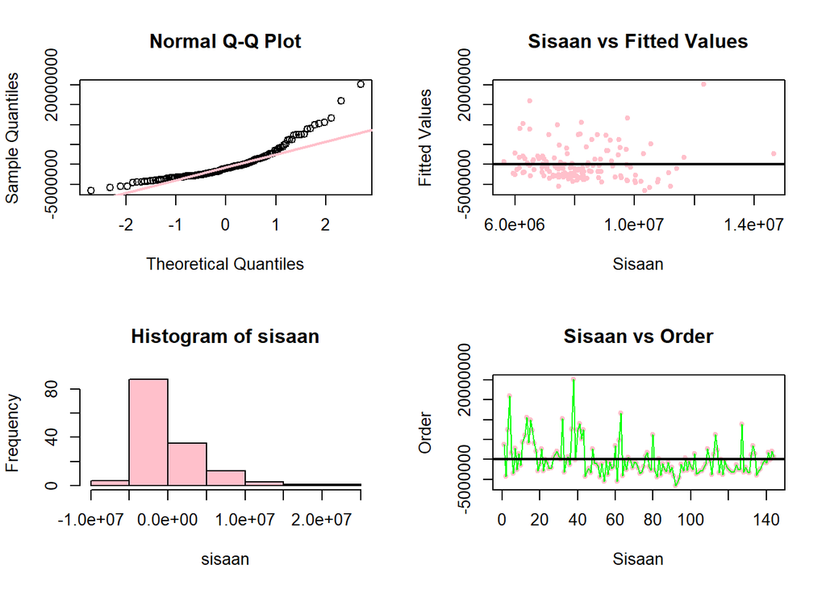

```r
#sisaan dan fitted value
sisaan<- residuals(reg)
fitValue<- predict(reg)

#Diagnostik dengan eksploratif
par(mfrow = c(2,2))
qqnorm(sisaan)
qqline(sisaan, col = "pink", lwd = 2)
plot(fitValue, sisaan, col = "pink", pch = 20, xlab = "Sisaan", ylab = "Fitted Values", main = "Sisaan vs Fitted Values")
abline(a = 0, b = 0, lwd = 2)
hist(sisaan, col = "pink")
plot(seq(1,144,1), sisaan, col = "pink", pch = 20, xlab = "Sisaan", ylab = "Order", main = "Sisaan vs Order")
lines(seq(1,144,1), sisaan, col = "green")
abline(a = 0, b = 0, lwd = 2)
```

### Uji formal normalitas

```r
#H0: sisaan mengikuti sebaran normal
#H1: sisaan tidak mengikuti sebaran normal
ks.test(sisaan, "pnorm", mean=mean(sisaan), sd=sd(sisaan))
```

```
##
##  Asymptotic one-sample Kolmogorov-Smirnov test
##
## data:  sisaan
## D = 0.14907, p-value = 0.003324
## alternative hypothesis: two-sided
```

### Transformasi menggunakan ln

```r
tinggi2 <- ln(tinggi)
rendah2 <- ln(rendah)
total2 <- ln(total)
model2 <- lm(total2 ~ tinggi2 + rendah2)
summary(model2)
```

```
##
## Call:
## lm(formula = total2 ~ tinggi2 + rendah2)
##
## Residuals:
##      Min       1Q   Median       3Q      Max
## -1.25373 -0.35085 -0.04477  0.26865  1.29158
##
## Coefficients:
##             Estimate Std. Error t value Pr(>|t|)
## (Intercept)   14.016      2.201   6.368 2.52e-09 ***
## tinggi2       23.025      6.031   3.817 0.000201 ***
## rendah2      -22.501      5.846  -3.849 0.000179 ***
## ---
## Signif. codes:  0 '***' 0.001 '**' 0.01 '*' 0.05 '.' 0.1 ' ' 1
##
## Residual standard error: 0.4475 on 141 degrees of freedom
##   (7 observations deleted due to missingness)
## Multiple R-squared:  0.09509,    Adjusted R-squared:  0.08226
## F-statistic: 7.409 on 2 and 141 DF,  p-value: 0.000872
```

### Uji kembali terhadap sisaan

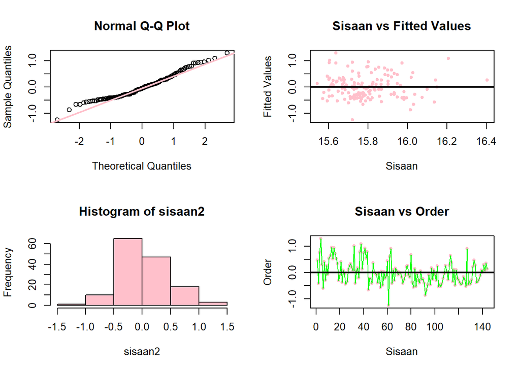

```r
#sisaan dan fitted value
sisaan2<- residuals(model2)
fitValue2<- predict(model2)

#Diagnostik dengan eksploratif
par(mfrow = c(2,2))
qqnorm(sisaan2)
qqline(sisaan2, col = "pink", lwd = 2)
plot(fitValue2, sisaan2, col = "pink", pch = 20, xlab = "Sisaan", ylab = "Fitted Values", main = "Sisaan vs Fitted Values")
abline(a = 0, b = 0, lwd = 2)
hist(sisaan2, col = "pink")
plot(seq(1,144,1), sisaan2, col = "pink", pch = 20, xlab = "Sisaan", ylab = "Order", main = "Sisaan vs Order")
lines(seq(1,144,1), sisaan2, col = "green")
abline(a = 0, b = 0, lwd = 2)
```

### Cek kembali uji formal normalitas

```r
#H0: sisaan mengikuti sebaran normal
#H1: sisaan tidak mengikuti sebaran normal
ks.test(sisaan2, "pnorm", mean=mean(sisaan2), sd=sd(sisaan2))
```

```
##
##  Asymptotic one-sample Kolmogorov-Smirnov test
##
## data:  sisaan2
## D = 0.083391, p-value = 0.2693
## alternative hypothesis: two-sided
```

### Uji untuk identifikasi autokorelasi

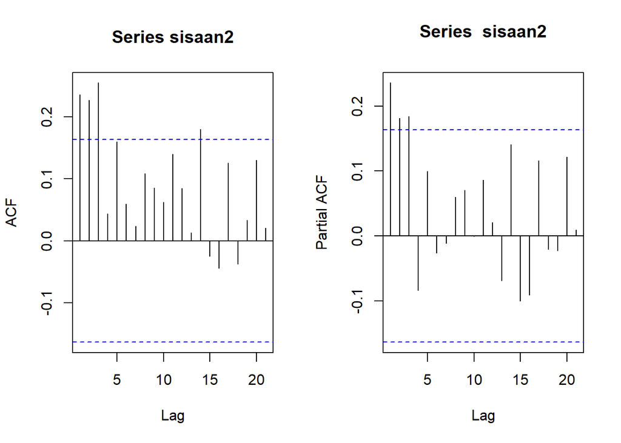

```r
par(mfrow = c(1,2))
acf(sisaan2)
pacf(sisaan2)
```

Berdasarkan plot ACF dan PACF, terlihat terdapat data yang berada diluar rentang batas sehingga ada yang signifikan. Namun, untuk lebih memastikan akan dilakukan uji formal dengan uji Durbin Watson.

### Uji Durbin Watson

```r
dwtest(model2)
```

```
##
##  Durbin-Watson test
##
## data:  model2
## DW = 1.5205, p-value = 0.001322
## alternative hypothesis: true autocorrelation is greater than 0
```

Berdasarkan hasil DW Test, didapatkan nilai $DW = 1.5205$ dan *p-value* = $0.001322$. Berdasarkan tabel Durbin-Watson diperoleh nilai $DL = 0.9771$ dan $DU = 1.331$. Dengan nilai *p-value* < 0.05 dapat disimpulkan bahwa tolak H0, cukup bukti mengatakan adanya autokorelasi. Oleh karena itu, diperlukan penangan autokorelasi.

## Metode Cochrane-Orcutt

```r
#Penanganan Autokorelasi Cochrane-Orcutt
Co<-cochrane.orcutt(model2)
Co
```

```
## Cochrane-orcutt estimation for first order autocorrelation
##
## Call:
## lm(formula = total2 ~ tinggi2 + rendah2)
##
##  number of interaction: 5
##  rho 0.239726
##
## Durbin-Watson statistic
## (original):    1.52055 , p-value: 1.322e-03
## (transformed): 2.05836 , p-value: 6.068e-01
##
##  coefficients:
## (Intercept)     tinggi2     rendah2
##    14.44100    20.38602   -20.00828
```

```r
Co$coefficients
```

```
## (Intercept)     tinggi2     rendah2
##    14.44100    20.38602   -20.00828
```

Hasil keluaran model setelah dilakukan penanganan adalah sebagai berikut.
$$y_i= 14.44100 + 20.38602x1_t -
20.00828x2_t$$
Hasil juga menunjukkan bahwa nilai DW dan p-value meningkat menjadi $2.05836$ dan $0.6068$. dengan nilai *p-value* > 0.05, artinya belum cukup bukti menyatakan bahwa sisaan terdapat autokorelasi pada taraf nyata 5%. Untuk nilai $ρ ̂$ optimum yang digunakan adalah $0.239726$. Nilai tersebut dapat diketahui dengan *syntax* berikut.

## Rho optimum

```r
rho <- Co$rho
rho
```

```
## [1] 0.2397258
```

## Transformasi manual

```r
#Pendefinisian peubah
totalman<- total2[-1]-total2[-144]*rho
highman<- tinggi2[-1]-tinggi2[-144]*rho
lowman<- rendah2[-1]-rendah2[-144]*rho
Coman<- lm(totalman~highman+lowman)
summary(Coman)
```

```
##
## Call:
## lm(formula = totalman ~ highman + lowman)
##
## Residuals:
##      Min       1Q   Median       3Q      Max
## -1.37625 -0.30557 -0.04851  0.25950  1.09549
##
## Coefficients:
##             Estimate Std. Error t value Pr(>|t|)
## (Intercept)   10.979      2.081   5.275 4.94e-07 ***
## highman       20.386      6.086   3.350 0.001039 **
## lowman       -20.008      5.899  -3.392 0.000904 ***
## ---
## Signif. codes:  0 '***' 0.001 '**' 0.01 '*' 0.05 '.' 0.1 ' ' 1
##
## Residual standard error: 0.4344 on 140 degrees of freedom
##   (7 observations deleted due to missingness)
## Multiple R-squared:  0.07593,    Adjusted R-squared:  0.06273
## F-statistic: 5.752 on 2 and 140 DF,  p-value: 0.003974
```

```r
#Mencari Penduga Koefisien Regresi setelah Transformasi ke Persamaan Awal
b0.1 <- Coman$coefficients[1]
b0baru<- b0.1/(1-rho)
b1baru <- Coman$coefficients[2]
b2baru <- Coman$coefficients[3]
b0baru
```

```
## (Intercept)
##      14.441
```

```r
b1baru
```

```
##  highman
## 20.38602
```

```r
b2baru
```

```
##    lowman
## -20.00828
```

Hasil perhitungan koefisien regresi tersebut akan menghasilkan hasil yang sama dengan model yang dihasilkan menggunakan *packages*.

## Metode Hildreth-Lu

```r
hildreth.lu.func<- function(r, reg){
  x1 <- model.matrix(reg)[,c(-1,-3)]
  x2 <- model.matrix(reg)[,c(-1,-2)]
  y <- model.response(model.frame(reg))
  n <- length(y)
  t <- 2:n
  y <- y[t]-r*y[t-1]
  x1 <- x1[t]-r*x1[t-1]
  x2 <- x2[t]-r*x2[t-1]

  return(lm(y~x1+x2))
}

#Pencarian rho yang meminimumkan SSE
ro.1 <- c(seq(0.1,0.9, by= 0.1))
tab1 <- data.frame("rho" = ro.1, "SSE" = sapply(ro.1, function(i){deviance(hildreth.lu.func(i, model2))}))
tab1
```

| rho | SSE |
| --- | --- |
| 0.1 | 26.95975 |
| 0.2 | 26.45951 |
| 0.3 | 26.51692 |
| 0.4 | 27.13343 |
| 0.5 | 28.31101 |
| 0.6 | 30.05164 |
| 0.7 | 32.35689 |
| 0.8 | 35.22774 |
| 0.9 | 38.66551 |

```r
#Rho optimal sekitar 0.2
ro.2<- seq(0.1,0.3, by= 0.001)
tab.1 <- data.frame("rho" = ro.2, "SSE" = sapply(ro.2, function(i){deviance(hildreth.lu.func(i, model2))}))
head(tab.1[order(tab.1$SSE),])
```

|  | rho | SSE |
| --- | --- | --- |
| 141 | 0.240 | 26.41549 |
| 140 | 0.239 | 26.41550 |
| 142 | 0.241 | 26.41553 |
| 139 | 0.238 | 26.41557 |
| 143 | 0.242 | 26.41563 |
| 138 | 0.237 | 26.41570 |

[figure not shown]

```r
#Grafik SSE optimum
par(mfrow = c(1,1))
plot(tab1$SSE ~ tab1$rho , type = "l", xlab = "Rho", ylab = "SSE")
abline(v = tab.1[tab.1$SSE==min(tab.1$SSE),"rho"], lty = 2, col="red",lwd=2)
text(x=0.32, y=28, labels = "rho=0.269", cex = 0.8)
```

Perhitungan yang dilakukan aplikasi `R` menunjukkan bahwa nilai $ρ$ optimum, yaitu saat SSE terkecil terdapat pada nilai $ρ=0.240$.

```r
#Model terbaik
modelHL2 <- hildreth.lu.func(0.24, model2)
summary(modelHL2)
```

```
##
## Call:
## lm(formula = y ~ x1 + x2)
##
## Residuals:
##      Min       1Q   Median       3Q      Max
## -1.37639 -0.30555 -0.04832  0.25951  1.09526
##
## Coefficients:
##             Estimate Std. Error t value Pr(>|t|)
## (Intercept)   10.975      2.081   5.273 4.97e-07 ***
## x1            20.384      6.086   3.349 0.001041 **
## x2           -20.006      5.900  -3.391 0.000905 ***
## ---
## Signif. codes:  0 '***' 0.001 '**' 0.01 '*' 0.05 '.' 0.1 ' ' 1
##
## Residual standard error: 0.4344 on 140 degrees of freedom
## Multiple R-squared:  0.07592,    Adjusted R-squared:  0.06272
## F-statistic: 5.751 on 2 and 140 DF,  p-value: 0.003979
```

```r
#Transformasi Balik
cat("y = ", coef(modelHL2)[1]/(1-0.24), "+", coef(modelHL2)[2],"x1","+", coef(modelHL2)[3],"x2", sep = "")
```

```
## y = 14.44138+20.38372x1+-20.00611x2
```

Setelah dilakukan tranformasi balik, didapatkan model dengan metode Hildreth-Lu sebagai berikut.
$$y_i= 14.44138
+ 20.38372x1_t - 20.00611x2_t$$

## Deteksi autokorelasi

```r
dwtest(modelHL2)
```

```
##
##  Durbin-Watson test
##
## data:  modelHL2
## DW = 2.059, p-value = 0.6083
## alternative hypothesis: true autocorrelation is greater than 0
```

Hasil uji Durbin-Watson juga menunjukkan bawah nilai DW sebesar $2.059$ berada pada selang daerah tidak ada autokorelasi, yaitu pada rentang DU < DW < 4-DU atau $1.331 < DW < 2.669$. Hal tersebut juga didukung oleh *p-value* sebesar $0.6083$, di mana *p-value* > $\alpha$=5%. Artinya tak tolak $H_0$ atau belum cukup bukti menyatakan bahwa ada autokorelasi dalam data dengan metode Hildreth-Lu pada taraf nyata 5%.

# Perbandingan keakuratan

```r
sseModelawal1 <- anova(model2)$`Sum Sq`[c(-1,-2)]
sseModelCO1 <- anova(Coman)$`Sum Sq`[c(-1,-2)]
sseModelHL1 <- anova(modelHL2)$`Sum Sq`[c(-1,-2)]
mseModelawal1 <- sseModelawal1/length(total2)
mseModelCO1 <- sseModelCO1/length(total2)
mseModelHL1 <- sseModelHL1/length(total2)
akurasi1 <- matrix(c(sseModelawal1,sseModelCO1,sseModelHL1,
                    mseModelawal1,mseModelCO1,mseModelHL1),nrow=2,ncol=3,byrow = T)
colnames(akurasi1) <- c("Model Awal", "Model Cochrane-Orcutt", "Model Hildreth-Lu")
row.names(akurasi1) <- c("SSE","MSE")
akurasi1
```

```
##     Model Awal Model Cochrane-Orcutt Model Hildreth-Lu
## SSE 28.2356025             26.415489         26.415491
## MSE  0.1869907              0.174937          0.174937
```

# Simpulan

Autokorelasi yang terdapat pada data Volume terjadi akibat adanya korelasi di antara unsur penyusunnya. Adanya autokorelasi menyebabkan model regresi kurang baik karena akan meningkatkan galatnya. Autokorelasi dapat dideteksi secara eksploratif melalui plot sisaan, ACF, dan PACF, serta dengan uji formal Durbin-Watson. Namun, autokorelasi tersebut dapat ditangani dengan metode Cochrane-Orcutt. Metode tersebut menghasilkan nilai SSE yang lebih kecil dibandingkan model awal dan penanganan menggunakan Hildreth-Lu. Artinya model Cochrane-Orcutt baik untuk digunakan dalam penanganan data diatas.